# R Notebook

**Principles of Data Visualization and Introduction to ggplot2**

I have provided you with data about the 5,000 fastest growing companies in the US, as compiled by Inc. magazine. lets read this in:

```r
library(ggplot2)
library(tidyverse)
inc <- read.csv("https://raw.githubusercontent.com/charleyferrari/CUNY_DATA_608/master/module1/Data/inc5000_data.csv", header= TRUE)
```

And lets preview this data:

```r
head(inc)
```

```
##   Rank                         Name Growth_Rate   Revenue
## 1    1                         Fuhu      421.48 1.179e+08
## 2    2        FederalConference.com      248.31 4.960e+07
## 3    3                The HCI Group      245.45 2.550e+07
## 4    4                      Bridger      233.08 1.900e+09
## 5    5                       DataXu      213.37 8.700e+07
## 6    6 MileStone Community Builders      179.38 4.570e+07
##                       Industry Employees         City State
## 1 Consumer Products & Services       104   El Segundo    CA
## 2          Government Services        51     Dumfries    VA
## 3                       Health       132 Jacksonville    FL
## 4                       Energy        50      Addison    TX
## 5      Advertising & Marketing       220       Boston    MA
## 6                  Real Estate        63       Austin    TX
```

```r
summary(inc)
```

```
##       Rank                          Name       Growth_Rate
##  Min.   :   1   (Add)ventures         :   1   Min.   :  0.340
##  1st Qu.:1252   @Properties           :   1   1st Qu.:  0.770
##  Median :2502   1-Stop Translation USA:   1   Median :  1.420
##  Mean   :2502   110 Consulting        :   1   Mean   :  4.612
##  3rd Qu.:3751   11thStreetCoffee.com  :   1   3rd Qu.:  3.290
##  Max.   :5000   123 Exteriors         :   1   Max.   :421.480
##                 (Other)               :4995
##     Revenue                                  Industry      Employees
##  Min.   :2.000e+06   IT Services                 : 733   Min.   :    1.0
##  1st Qu.:5.100e+06   Business Products & Services: 482   1st Qu.:   25.0
##  Median :1.090e+07   Advertising & Marketing     : 471   Median :   53.0
##  Mean   :4.822e+07   Health                      : 355   Mean   :  232.7
##  3rd Qu.:2.860e+07   Software                    : 342   3rd Qu.:  132.0
##  Max.   :1.010e+10   Financial Services          : 260   Max.   :66803.0
##                      (Other)                     :2358   NA's   :12
##             City          State
##  New York     : 160   CA     : 701
##  Chicago      :  90   TX     : 387
##  Austin       :  88   NY     : 311
##  Houston      :  76   VA     : 283
##  San Francisco:  75   FL     : 282
##  Atlanta      :  74   IL     : 273
##  (Other)      :4438   (Other):2764
```

Think a bit on what these summaries mean. Use the space below to add some more relevant non-visual exploratory information you think helps you understand this data:

```r
# Insert your code here, create more chunks as necessary
inc %>% group_by(State) %>% summarise(Count= n(),mean_rev = mean(Revenue), sd_rev = sd(Revenue), R_SD_ALL= sd(Revenue)/sd(inc$Revenue)) %>% arrange(.,desc(R_SD_ALL))
```

```
## # A tibble: 52 x 5
##    State Count   mean_rev     sd_rev R_SD_ALL
##    <fct> <int>      <dbl>      <dbl>    <dbl>
##  1 IL      273 121773993. 702149071.    2.92
##  2 ID       17 231523529. 686093884.    2.85
##  3 WI       79  92362025. 529764518.    2.20
##  4 IA       28 123142857. 525683101.    2.19
##  5 NY      311  58715113. 341922076.    1.42
##  6 NC      137  67580292. 312739773.    1.30
##  7 DC       43  76344186. 273303810.    1.14
##  8 OH      186  68745161. 261035147.    1.09
##  9 AK        2 171500000  235890822.    0.981
## 10 MN       88  57256818. 226032974.    0.940
## # ... with 42 more rows
```

In my data I could see that there are Eight sates that did better than the natioanl std deviation of the Revenue.It seem like IL is having more potential with less number of company they were able to produce such a Revenue. ## Question 1

Create a graph that shows the distribution of companies in the dataset by State (ie how many are in each state). There are a lot of States, so consider which axis you should use. This visualization is ultimately going to be consumed on a ‘portrait’ oriented screen (ie taller than wide), which should further guide your layout choices.

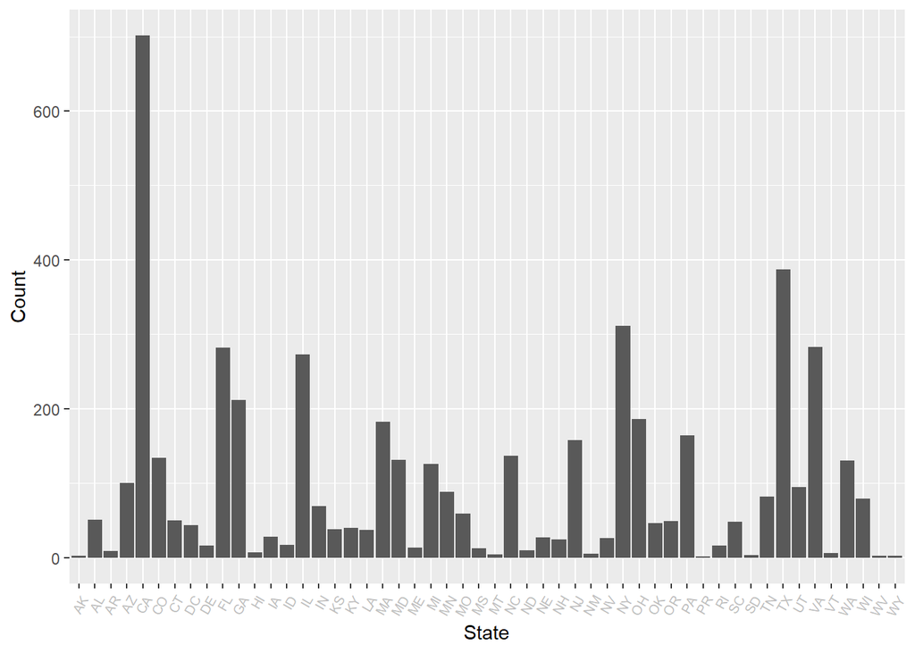

```r
# Answer Question 1 here
inc %>%
  group_by(State) %>%
  summarise(Count= n()) %>%
  ggplot(mapping = aes(x= State, y=Count)) +
  geom_col()+
  theme(axis.text.x = element_text(angle = 60, colour="gray",hjust = 1,size=rel(0.86)))
```

## Quesiton 2

Lets dig in on the state with the 3rd most companies in the data set. Imagine you work for the state and are interested in how many people are employed by companies in different industries. Create a plot that shows the average and/or median employment by industry for companies in this state (only use cases with full data, use R’s `complete.cases()` function.) In addition to this, your graph should show how variable the ranges are, and you should deal with outliers.

```r
# Answer Question 2 here
# Third most company in the dataset
inc %>%
  group_by(State) %>%
  summarise(Count= n()) %>%
  arrange(.,desc(Count)) %>% .[3,]
```

```
## # A tibble: 1 x 2
##   State Count
##   <fct> <int>
## 1 NY      311
```

```r
# how many people are employed by companies in different industries.
inc %>% filter(.,State== "NY") %>%
  plyr::ddply(.,'Industry',summarise,E_Count = sum(Employees))
```

```
##                        Industry E_Count
## 1       Advertising & Marketing    3331
## 2  Business Products & Services   38804
## 3             Computer Hardware      44
## 4                  Construction     366
## 5  Consumer Products & Services   10647
## 6                     Education     838
## 7                        Energy     646
## 8                   Engineering     214
## 9        Environmental Services     310
## 10           Financial Services    1876
## 11              Food & Beverage     688
## 12          Government Services      17
## 13                       Health    1064
## 14              Human Resources    4813
## 15                    Insurance      65
## 16                  IT Services    8776
## 17   Logistics & Transportation     118
## 18                Manufacturing     953
## 19                        Media    1188
## 20                  Real Estate      73
## 21                       Retail     347
## 22                     Security     540
## 23                     Software    3197
## 24           Telecommunications    1621
## 25         Travel & Hospitality    3834
```

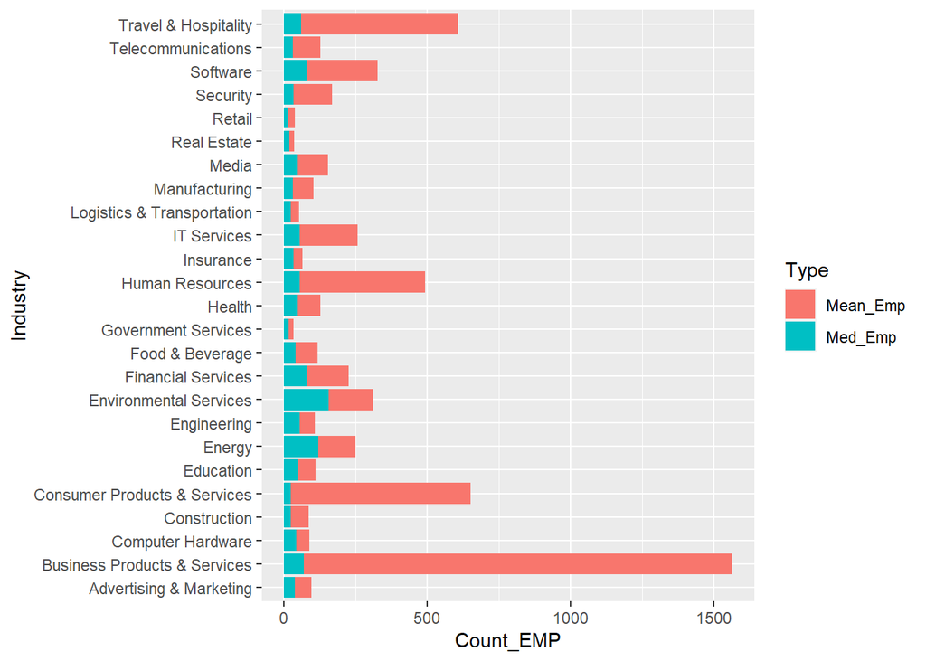

```r
# Create a plot that shows the average and/or median employment by industry for companies in this state
inc %>% filter(.,State== "NY") %>%
  plyr::ddply(.,'Industry',summarise,E_Count = sum(Employees),Mean_Emp = mean(Employees), Med_Emp=median(Employees))  %>% gather(key="Type" , value = "Count_EMP","Mean_Emp","Med_Emp","E_Count") %>% .[which(.$Type %in% c("Mean_Emp","Med_Emp")),] %>%
  ggplot(mapping = aes(y= Industry, x=Count_EMP,fill = Type)) +
  geom_col()
```

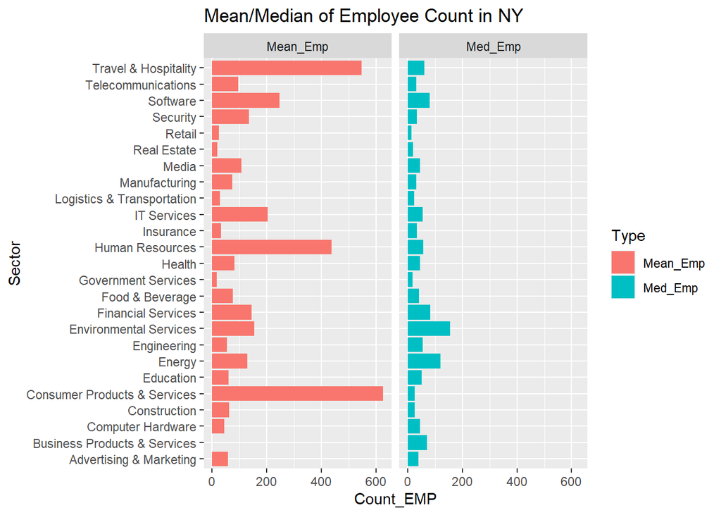

```r
#Taking care of outliers

inc %>% filter(.,State== "NY") %>%
  plyr::ddply(.,'Industry',summarise,E_Count = sum(Employees),Mean_Emp = mean(Employees), Med_Emp=median(Employees))  %>% gather(key="Type" , value = "Count_EMP","Mean_Emp","Med_Emp","E_Count") %>% .[which(.$Type %in% c("Mean_Emp","Med_Emp")),] %>% .[-which(.$Count_EMP > 1000),] %>%
  ggplot(mapping = aes(y= Industry, x=Count_EMP,fill = Type)) +
  geom_col() +
  labs(title = "Mean/Median of Employee Count in NY",
       y = "Sector") +
  facet_wrap(~Type)
```

## Question 3

Now imagine you work for an investor and want to see which industries generate the most revenue per employee. Create a chart that makes this information clear. Once again, the distribution per industry should be shown.

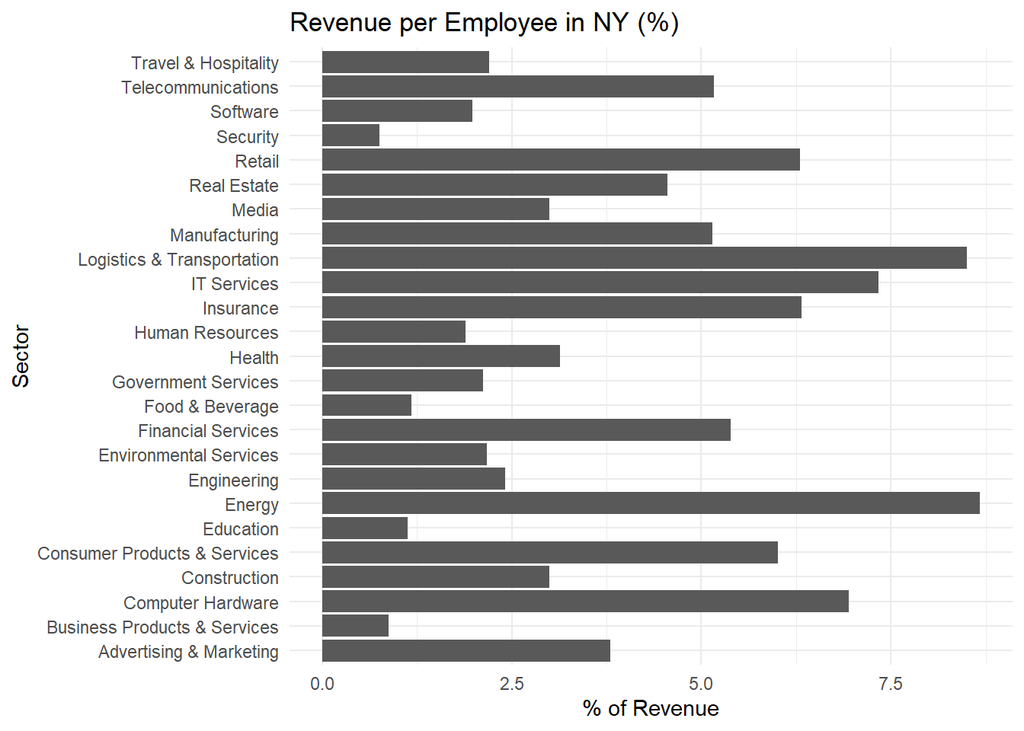

```r
# Answer Question 3 here

SUM_NY_TOTL_REV <- inc %>% filter(.,State== "NY") %>%     plyr::ddply(.,'Industry',summarise,
                                                   Rev_Per_Emp = sum(Revenue)/sum(Employees)) %>% .[,"Rev_Per_Emp"] %>% sum(.)
inc %>% filter(.,State== "NY") %>%     plyr::ddply(.,'Industry',summarise,
                                                   Rev_Per_Emp = sum(Revenue)/sum(Employees),
                                                   p=( Rev_Per_Emp*100)/SUM_NY_TOTL_REV)%>%
  ggplot(mapping = aes(y= Industry, x=(p))) +
   geom_bar(stat = "identity") +
   labs(title = "Revenue per Employee in NY (%) ", y = "Sector",  x = "% of Revenue") +  theme_minimal()
```